# CP01

Jose López Galdón

28/10/2020

### ENLACE A GITHUB: *https://github.com/jlopezgaldon/prediction/blob/main/CP01/CP01_v1.Rmd*

## CARGAMOS LOS DATOS

Visualizamos los datos.

```r
data_nba
```

```
## # A tibble: 485 x 28
##    Player Salary NBA_Country NBA_DraftNumber   Age Tm        G    MP   PER `TS%`
##    <chr>   <dbl> <chr>                 <dbl> <dbl> <chr> <dbl> <dbl> <dbl> <dbl>
##  1 Zhou ~ 8.16e5 China                    43    22 HOU      16    87   0.6 0.303
##  2 Zaza ~ 3.48e6 Georgia                  42    33 GSW      66   937  16.8 0.608
##  3 Zach ~ 1.23e7 USA                      19    36 SAC      59  1508  17.3 0.529
##  4 Zach ~ 3.20e6 USA                      13    22 CHI      24   656  14.6 0.499
##  5 Zach ~ 3.06e6 USA                      10    20 POR      62   979   8.2 0.487
##  6 Yogi ~ 1.31e6 USA                      62    24 DAL      79  2238  11.5 0.543
##  7 Xavie~ 7.42e4 USA                      62    30 BOS       2     7  -4.9 0
##  8 Xavie~ 4.61e4 Canada                   62    23 MEM       5   118   0.9 0.315
##  9 Wilso~ 1.20e7 USA                      23    30 DEN      70  2200  11.1 0.543
## 10 Willy~ 1.44e6 Spain                    35    23 TOT      45   430  20.6 0.592
## # ... with 475 more rows, and 18 more variables: `3PAr` <dbl>, FTr <dbl>,
## #   `ORB%` <dbl>, `DRB%` <dbl>, `TRB%` <dbl>, `AST%` <dbl>, `STL%` <dbl>,
## #   `BLK%` <dbl>, `TOV%` <dbl>, `USG%` <dbl>, OWS <dbl>, DWS <dbl>, WS <dbl>,
## #   `WS/48` <dbl>, OBPM <dbl>, DBPM <dbl>, BPM <dbl>, VORP <dbl>
```

## LIMPIEZA DEL DATASET

### Duplicados

Comenzamos analizando los valores duplicados, para posteriormente eliminarlos.

```r
# Observamos que cuantos valores duplicados tenemos
nrow(data_nba[duplicated(data_nba$Player), ])
```

```
## [1] 2
```

En este caso tenemos 2 jugadores repetidos.

```r
# Para eliminar los jugadores repetidos:
data_nba <- data_nba[!duplicated(data_nba$Player), ]
data_nba
```

```
## # A tibble: 483 x 28
##    Player Salary NBA_Country NBA_DraftNumber   Age Tm        G    MP   PER `TS%`
##    <chr>   <dbl> <chr>                 <dbl> <dbl> <chr> <dbl> <dbl> <dbl> <dbl>
##  1 Zhou ~ 8.16e5 China                    43    22 HOU      16    87   0.6 0.303
##  2 Zaza ~ 3.48e6 Georgia                  42    33 GSW      66   937  16.8 0.608
##  3 Zach ~ 1.23e7 USA                      19    36 SAC      59  1508  17.3 0.529
##  4 Zach ~ 3.20e6 USA                      13    22 CHI      24   656  14.6 0.499
##  5 Zach ~ 3.06e6 USA                      10    20 POR      62   979   8.2 0.487
##  6 Yogi ~ 1.31e6 USA                      62    24 DAL      79  2238  11.5 0.543
##  7 Xavie~ 7.42e4 USA                      62    30 BOS       2     7  -4.9 0
##  8 Xavie~ 4.61e4 Canada                   62    23 MEM       5   118   0.9 0.315
##  9 Wilso~ 1.20e7 USA                      23    30 DEN      70  2200  11.1 0.543
## 10 Willy~ 1.44e6 Spain                    35    23 TOT      45   430  20.6 0.592
## # ... with 473 more rows, and 18 more variables: `3PAr` <dbl>, FTr <dbl>,
## #   `ORB%` <dbl>, `DRB%` <dbl>, `TRB%` <dbl>, `AST%` <dbl>, `STL%` <dbl>,
## #   `BLK%` <dbl>, `TOV%` <dbl>, `USG%` <dbl>, OWS <dbl>, DWS <dbl>, WS <dbl>,
## #   `WS/48` <dbl>, OBPM <dbl>, DBPM <dbl>, BPM <dbl>, VORP <dbl>
```

Ahora ya tenemos el dataset sin valores repetidos.

### Valores nulos

A continuación, contaremos los valores nulos para ver si tenemos en el dataset:

```r
summarise_all(data_nba, funs(sum(is.na(.))))
```

```
## # A tibble: 1 x 28
##   Player Salary NBA_Country NBA_DraftNumber   Age    Tm     G    MP   PER `TS%`
##    <int>  <int>       <int>           <int> <int> <int> <int> <int> <int> <int>
## 1      0      0           0               0     0     0     0     0     0     2
## # ... with 18 more variables: `3PAr` <int>, FTr <int>, `ORB%` <int>,
## #   `DRB%` <int>, `TRB%` <int>, `AST%` <int>, `STL%` <int>, `BLK%` <int>,
## #   `TOV%` <int>, `USG%` <int>, OWS <int>, DWS <int>, WS <int>, `WS/48` <int>,
## #   OBPM <int>, DBPM <int>, BPM <int>, VORP <int>
```

Como podemos observar tenemos varios valores nulos en algunas de las columnas. Probaremos eliminandolos.

```r
data_nba <- na.omit(data_nba)

summarise_all(data_nba, funs(sum(is.na(.))))
```

```
## # A tibble: 1 x 28
##   Player Salary NBA_Country NBA_DraftNumber   Age    Tm     G    MP   PER `TS%`
##    <int>  <int>       <int>           <int> <int> <int> <int> <int> <int> <int>
## 1      0      0           0               0     0     0     0     0     0     0
## # ... with 18 more variables: `3PAr` <int>, FTr <int>, `ORB%` <int>,
## #   `DRB%` <int>, `TRB%` <int>, `AST%` <int>, `STL%` <int>, `BLK%` <int>,
## #   `TOV%` <int>, `USG%` <int>, OWS <int>, DWS <int>, WS <int>, `WS/48` <int>,
## #   OBPM <int>, DBPM <int>, BPM <int>, VORP <int>
```

Como podemos observar ya no existen valores null en ninguna de las columnas.

### Renombrar columnas

El problema que tenemos, es que los nombres de las columnas no tienen el formato adecuado, esto es porque presentas símbolos como %. Por lo que cambiaremos los nombres a minusculas y sustituiremos dichos símbolos.

```r
# Cambiamos los nombres de las variables a minusculas y sustituimos los % por ""
data_nba <- rename_with(data_nba, ~ tolower(gsub("%", "", .x, fixed = TRUE)))

# Cambiamos el 3par por triplepar
data_nba <- rename_with(data_nba, ~ (gsub("3", "triple", .x, fixed = TRUE)))

# Cambiamos el ws/48 por ws48
data_nba <- rename_with(data_nba, ~ (gsub("/", "_", .x, fixed = TRUE)))

# Comprobamos el dataset
data_nba
```

```
## # A tibble: 481 x 28
##    player salary nba_country nba_draftnumber   age tm        g    mp   per    ts
##    <chr>   <dbl> <chr>                 <dbl> <dbl> <chr> <dbl> <dbl> <dbl> <dbl>
##  1 Zhou ~ 8.16e5 China                    43    22 HOU      16    87   0.6 0.303
##  2 Zaza ~ 3.48e6 Georgia                  42    33 GSW      66   937  16.8 0.608
##  3 Zach ~ 1.23e7 USA                      19    36 SAC      59  1508  17.3 0.529
##  4 Zach ~ 3.20e6 USA                      13    22 CHI      24   656  14.6 0.499
##  5 Zach ~ 3.06e6 USA                      10    20 POR      62   979   8.2 0.487
##  6 Yogi ~ 1.31e6 USA                      62    24 DAL      79  2238  11.5 0.543
##  7 Xavie~ 7.42e4 USA                      62    30 BOS       2     7  -4.9 0
##  8 Xavie~ 4.61e4 Canada                   62    23 MEM       5   118   0.9 0.315
##  9 Wilso~ 1.20e7 USA                      23    30 DEN      70  2200  11.1 0.543
## 10 Willy~ 1.44e6 Spain                    35    23 TOT      45   430  20.6 0.592
## # ... with 471 more rows, and 18 more variables: triplepar <dbl>, ftr <dbl>,
## #   orb <dbl>, drb <dbl>, trb <dbl>, ast <dbl>, stl <dbl>, blk <dbl>,
## #   tov <dbl>, usg <dbl>, ows <dbl>, dws <dbl>, ws <dbl>, ws_48 <dbl>,
## #   obpm <dbl>, dbpm <dbl>, bpm <dbl>, vorp <dbl>
```

Ahora ya tenemos el dataset listo para trabajar con el.

## DICCIONARIO DE VARIABLES

- player: Nombre del jugador.
- salary: Salario en dolares.
- nba_country: NAcionalidad del jugador.
- nba_draftnumber: Posición del draft.
- age: Edad del jugador.
- tm: Abreviatura del nombre.
- g: Partidos jugados.
- mp: Minutos jugados.
- per: Índice de eficiencia del jugador. El promedio de la liga es 15.
- ts = Porcentaje de tiro real. Tiene en cuenta los tiros de 2 puntos, los triples y los tiros libres.
- tmp: Minutos jugados por el equipo.
- triplepar: Porcentaje de triples.
- ftr: Porcentaje de tiros libres.
- orb: Porcentaje de rebotes ofensivos.
- drb: Porcentaje de rebote defensivo.
- trb: Porcentaje de rebote total.
- ast: Porcentaje de asistencia.
- stl: Porcentaje de robo.
- blk: Porcentaje de tapones.
- tov: Porcentaje de robo de balón antes de que el equipo contrario tire.
- usg: Porcentaje de jugadas que estuvo involucrado un jugador, siempre que la jugada termine en uno de los tres resultados reales: intento de gol de campo, intento de tiro libre o pérdida.
- ows: Acciones de victoria ofensivas.
- dws: Acciones de victorias defensivas.
- ws: Un número estimado de victorias a las que un jugador ha contribuido.
- ws_48: WS por 48 minutos.
- obpm: Calcula el más/menos de un jugador respecto al rendimiento del equipo por cada 100 posesiones ofensivas.
- dbpm: Calcula el más/menos de un jugador respecto al rendimiento del equipo por cada 100 posesiones defensivas.
- bpm: Calcula el más/menos de un jugador respecto al rendimiento del equipo por cada 100 posesiones.
- vorp: Valor sobre jugador de reemplazo.

## EDA

### Correlaciones

Haremos un pequeño análisis de las correlaciones para ver que variables están correlacionadas con el salario.

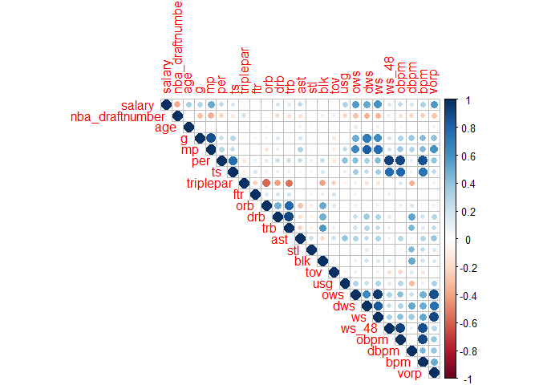

```r
# Eliminamos las variables player, nba_country y tm

corrplot(cor(data_nba %>%
                          select_at(vars(-(c(player, nba_country, tm)))),
              use = "complete.obs"),
         method = "circle", type = "upper")
```

Como podemos observar existe una cierta correlación positiva entre el salario, la edad, los partidos jugados, el numero de miutos jugados, per, rebotes ofensivos y defensivos, las acciones ofensivas y defensivas, las victorias y el valor sobre el jugador de reemplazao.

De esta manera ya tenemos una idea sobre las variables que pueden ser significativas en nuestro modelo.

## REGRESIÓN DEL MODELO 1

Comenzamos realizando la regresión linear del modelo:

```r
regresion_lm1 <- lm(salary ~ . - (player + nba_country + tm), data = data_nba)
summary(regresion_lm1)
```

```
##
## Call:
## lm(formula = salary ~ . - (player + nba_country + tm), data = data_nba)
##
## Residuals:
##       Min        1Q    Median        3Q       Max
## -15354874  -3000738   -385019   2114291  21684587
##
## Coefficients:
##                 Estimate Std. Error t value Pr(>|t|)
## (Intercept)     -2257549    4909948  -0.460    0.646
## nba_draftnumber   -60665      12807  -4.737 2.90e-06 ***
## age               517569      56727   9.124  < 2e-16 ***
## g                -154422      25036  -6.168 1.53e-09 ***
## mp                  5670       1087   5.217 2.76e-07 ***
## per              -353478     281293  -1.257    0.210
## ts              -2184162    5160879  -0.423    0.672
## triplepar       -3441403    2364332  -1.456    0.146
## ftr              -151800     889330  -0.171    0.865
## orb             -1067597     906856  -1.177    0.240
## drb              -868491     897793  -0.967    0.334
## trb              2033598    1797209   1.132    0.258
## ast               -19939      47665  -0.418    0.676
## stl              -194112     423061  -0.459    0.647
## blk               110027     318948   0.345    0.730
## tov                 4106      52808   0.078    0.938
## usg               167442     105277   1.590    0.112
## ows             -1323605    4518535  -0.293    0.770
## dws             -1790690    4544903  -0.394    0.694
## ws               1877630    4523606   0.415    0.678
## ws_48            1893689   11822704   0.160    0.873
## obpm             1935687    4772501   0.406    0.685
## dbpm             1494922    4687825   0.319    0.750
## bpm             -1353095    4705755  -0.288    0.774
## vorp              632085     635260   0.995    0.320
## ---
## Signif. codes:  0 '***' 0.001 '**' 0.01 '*' 0.05 '.' 0.1 ' ' 1
##
## Residual standard error: 5114000 on 456 degrees of freedom
## Multiple R-squared:  0.5469, Adjusted R-squared:  0.5231
## F-statistic: 22.94 on 24 and 456 DF,  p-value: < 2.2e-16
```

Como podemos observar son significativos *age*, *nba_draft_number*, *g* y *mp*. Como vemos el R2 ajustado es del 52.31%, es decir, el modelo solo explica el 52.31% de la variabilidad de los datos.

## EL MODELO:

El modelo tiene que cumplir las siguientes características:

1. El modelo es correcto: a. Es lineal b. Estas las variables adecuadas. c. No falta ninguna ni sobra.
2. La variable X no es aleatoria
3. El error tiene esperanza cero
4. Ausencia de Heteroscesdasticidad
5. Ausencia de Autocorrelación (solamente Series Temporales)
6. Normalidad de los errores

## ANÁLISIS DE RESIDUOS

### Validación global

A continuación, realizaremos un gvlma, este test nos indica los p-valores de:

- Asimetía
- Curtosis
- Link function
- Heteroscedasticidad
- Test global

```r
gvmodel <- gvlma(regresion_lm1)
summary(gvmodel)
```

```
##
## Call:
## lm(formula = salary ~ . - (player + nba_country + tm), data = data_nba)
##
## Residuals:
##       Min        1Q    Median        3Q       Max
## -15354874  -3000738   -385019   2114291  21684587
##
## Coefficients:
##                 Estimate Std. Error t value Pr(>|t|)
## (Intercept)     -2257549    4909948  -0.460    0.646
## nba_draftnumber   -60665      12807  -4.737 2.90e-06 ***
## age               517569      56727   9.124  < 2e-16 ***
## g                -154422      25036  -6.168 1.53e-09 ***
## mp                  5670       1087   5.217 2.76e-07 ***
## per              -353478     281293  -1.257    0.210
## ts              -2184162    5160879  -0.423    0.672
## triplepar       -3441403    2364332  -1.456    0.146
## ftr              -151800     889330  -0.171    0.865
## orb             -1067597     906856  -1.177    0.240
## drb              -868491     897793  -0.967    0.334
## trb              2033598    1797209   1.132    0.258
## ast               -19939      47665  -0.418    0.676
## stl              -194112     423061  -0.459    0.647
## blk               110027     318948   0.345    0.730
## tov                 4106      52808   0.078    0.938
## usg               167442     105277   1.590    0.112
## ows             -1323605    4518535  -0.293    0.770
## dws             -1790690    4544903  -0.394    0.694
## ws               1877630    4523606   0.415    0.678
## ws_48            1893689   11822704   0.160    0.873
## obpm             1935687    4772501   0.406    0.685
## dbpm             1494922    4687825   0.319    0.750
## bpm             -1353095    4705755  -0.288    0.774
## vorp              632085     635260   0.995    0.320
## ---
## Signif. codes:  0 '***' 0.001 '**' 0.01 '*' 0.05 '.' 0.1 ' ' 1
##
## Residual standard error: 5114000 on 456 degrees of freedom
## Multiple R-squared:  0.5469, Adjusted R-squared:  0.5231
## F-statistic: 22.94 on 24 and 456 DF,  p-value: < 2.2e-16
##
##
## ASSESSMENT OF THE LINEAR MODEL ASSUMPTIONS
## USING THE GLOBAL TEST ON 4 DEGREES-OF-FREEDOM:
## Level of Significance =  0.05
##
## Call:
##  gvlma(x = regresion_lm1)
##
##                       Value   p-value                   Decision
## Global Stat        115.6519 0.000e+00 Assumptions NOT satisfied!
## Skewness            32.2341 1.367e-08 Assumptions NOT satisfied!
## Kurtosis            50.9726 9.366e-13 Assumptions NOT satisfied!
## Link Function       31.9115 1.614e-08 Assumptions NOT satisfied!
## Heteroscedasticity   0.5336 4.651e-01    Assumptions acceptable.
```

## TRANSFORMACIÓN DEL MODELO

### Box-Cox

Mediante la función Box-Cox realizamos un contraste de hipótesis para ver si aplicamos la transformación logarítmica, si lamba (el parámetro de salida) es 0 o cercano a 0 podemos aplicar la transformación logarítmica, en caso de que sea distinto de 0 no se aplica.

```r
BoxCox.lambda(data_nba$salary)
```

```
## [1] 0.0259115
```

Como el resultado es cercano a 0 vamos a probar con la transformación logarítmica:

```r
data_log_nba <- data_nba %>%
                  mutate(salary = log(salary))

# Comprobamos que ha cambiado
data_log_nba
```

```
## # A tibble: 481 x 28
##    player salary nba_country nba_draftnumber   age tm        g    mp   per    ts
##    <chr>   <dbl> <chr>                 <dbl> <dbl> <chr> <dbl> <dbl> <dbl> <dbl>
##  1 Zhou ~   13.6 China                    43    22 HOU      16    87   0.6 0.303
##  2 Zaza ~   15.1 Georgia                  42    33 GSW      66   937  16.8 0.608
##  3 Zach ~   16.3 USA                      19    36 SAC      59  1508  17.3 0.529
##  4 Zach ~   15.0 USA                      13    22 CHI      24   656  14.6 0.499
##  5 Zach ~   14.9 USA                      10    20 POR      62   979   8.2 0.487
##  6 Yogi ~   14.1 USA                      62    24 DAL      79  2238  11.5 0.543
##  7 Xavie~   11.2 USA                      62    30 BOS       2     7  -4.9 0
##  8 Xavie~   10.7 Canada                   62    23 MEM       5   118   0.9 0.315
##  9 Wilso~   16.3 USA                      23    30 DEN      70  2200  11.1 0.543
## 10 Willy~   14.2 Spain                    35    23 TOT      45   430  20.6 0.592
## # ... with 471 more rows, and 18 more variables: triplepar <dbl>, ftr <dbl>,
## #   orb <dbl>, drb <dbl>, trb <dbl>, ast <dbl>, stl <dbl>, blk <dbl>,
## #   tov <dbl>, usg <dbl>, ows <dbl>, dws <dbl>, ws <dbl>, ws_48 <dbl>,
## #   obpm <dbl>, dbpm <dbl>, bpm <dbl>, vorp <dbl>
```

## REGRESIÓN DEL MODELO 2

Una vez tenemos modificado la base de datos, definiremos un nuevo modelo:

```r
regresion_lm2 <- lm(salary ~ . - (player + nba_country + tm), data = data_log_nba)
summary(regresion_lm2)
```

```
##
## Call:
## lm(formula = salary ~ . - (player + nba_country + tm), data = data_log_nba)
##
## Residuals:
##     Min      1Q  Median      3Q     Max
## -3.6467 -0.5503  0.0338  0.6031  3.3476
##
## Coefficients:
##                   Estimate Std. Error t value Pr(>|t|)
## (Intercept)     10.6956949  0.9742269  10.979  < 2e-16 ***
## nba_draftnumber -0.0220520  0.0025411  -8.678  < 2e-16 ***
## age              0.0994131  0.0112557   8.832  < 2e-16 ***
## g               -0.0050789  0.0049677  -1.022 0.307144
## mp               0.0010505  0.0002156   4.872 1.53e-06 ***
## per             -0.1836822  0.0558139  -3.291 0.001076 **
## ts               3.1723864  1.0240164   3.098 0.002069 **
## triplepar       -0.4079670  0.4691284  -0.870 0.384961
## ftr             -0.2894332  0.1764599  -1.640 0.101649
## orb             -0.0764709  0.1799375  -0.425 0.671047
## drb             -0.0631515  0.1781392  -0.355 0.723123
## trb              0.2063443  0.3566004   0.579 0.563116
## ast              0.0157191  0.0094577   1.662 0.097192 .
## stl              0.0359938  0.0839434   0.429 0.668281
## blk              0.0106909  0.0632854   0.169 0.865925
## tov             -0.0210089  0.0104781  -2.005 0.045551 *
## usg              0.0728828  0.0208889   3.489 0.000532 ***
## ows             -0.1698247  0.8965631  -0.189 0.849850
## dws             -0.4168086  0.9017950  -0.462 0.644159
## ws               0.1753680  0.8975693   0.195 0.845182
## ws_48            6.1696386  2.3458492   2.630 0.008827 **
## obpm            -0.5601645  0.9469549  -0.592 0.554450
## dbpm            -0.5030567  0.9301535  -0.541 0.588888
## bpm              0.5825235  0.9337111   0.624 0.533019
## vorp             0.0274218  0.1260476   0.218 0.827876
## ---
## Signif. codes:  0 '***' 0.001 '**' 0.01 '*' 0.05 '.' 0.1 ' ' 1
##
## Residual standard error: 1.015 on 456 degrees of freedom
## Multiple R-squared:  0.5586, Adjusted R-squared:  0.5354
## F-statistic: 24.04 on 24 and 456 DF,  p-value: < 2.2e-16
```

Además, hemos mejorado el R2 ajustado, en el modelo 1 era de 52.31% y en el modelo 2 es de 53.54%.

### Selección de variables

Podemos comparar modelos mediante el método de *Akaike’s Information Criterion(AIC)* y seleccionaremos aquel modelo que tenga menosr AIC. En este caso, compararemos el modelo 1 y el 2.

```r
AIC(regresion_lm1, regresion_lm2)
```

```
##               df       AIC
## regresion_lm1 26 16251.853
## regresion_lm2 26  1405.418
```

Como vemos el modelo 2 ( *regresion_lm2* ) es mucho mejor que el primer modelo que hemos definido, ya que el AIC es menor.

## ANÁLISIS DE RESIDUOS

### Normalidad

#### QQPLOT

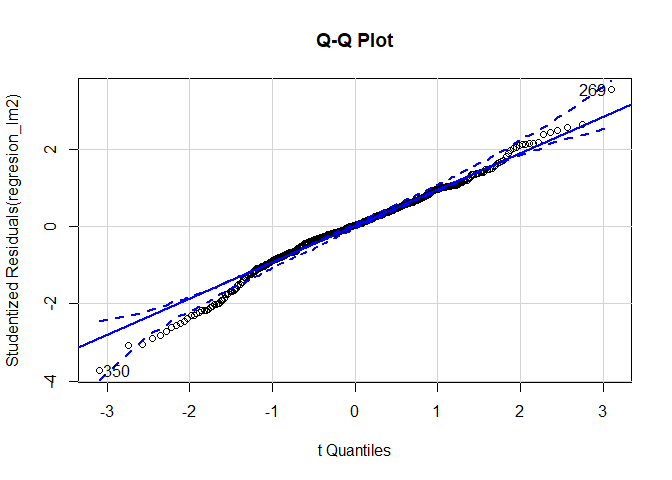

```
## [1] 269 350
```

```r
qqPlot(regresion_lm2, labels = row.names(data_nba), id.method = "identify", simulate = TRUE, main = "Q-Q Plot")
```

En este caso, al no seguir la recta azul contínua significa que no sigue una normalidad.

### Histograma, densidad, normal + rug

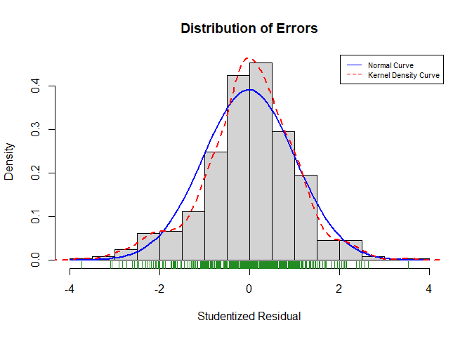

```r
# Definimos una función que nos permita hacer un plot del histograma, la función de densidad, la normal y el rug

residplot <- function(fit, nbreaks = 20) {
  z <- rstudent(fit)
  hist(z, breaks = nbreaks, freq = FALSE,
       xlab = "Studentized Residual",
       main = "Distribution of Errors")
  rug(jitter(z), col = "forestgreen")
  curve(dnorm(x, mean = mean(z), sd = sd(z)),
        add = TRUE, col = "blue", lwd = 2)
  lines(density(z)$x, density(z)$y,
        col = "red", lwd = 2, lty = 2)
  legend("topright",
         legend = c( "Normal Curve", "Kernel Density Curve"),
         lty = 1:2, col = c("blue", "red"), cex = 0.7)
}

residplot(regresion_lm2)
```

Como podemos observar nuestro modelo se llega acercar a una distribución normal pero no es una normal.

### Jarque Bera

El estadístico se distribuye como una chi-cuadrado de 2 grados de libertad, siendo la hipótesis nula que la distribución es normal (coeficiente de asimetría y curtosis es cero)

```r
vResid = resid(regresion_lm2)

jbTest(vResid)
```

```
##
## Title:
##  Jarque - Bera Normality Test
##
## Test Results:
##   PARAMETER:
##     Sample Size: 481
##   STATISTIC:
##     LM: 18.431
##     ALM: 19.272
##   P VALUE:
##     LM p-value: 0.002
##     ALM p-value: 0.002
##     Asymptotic: < 2.2e-16
##
## Description:
##  Tue Oct 27 20:47:35 2020 by user: jlope
```

Como el p-valor es menor a 0.05 rechazamos la hipótesis nula, es decir, nuestro modelo no sigue una distribución normal.

### Shapiro-Wilk

El test de Shapiro-Wilk permite comprobar si una muestra ha sido generada por un distribución normal.

```r
shapiro.test(vResid)
```

```
##
##  Shapiro-Wilk normality test
##
## data:  vResid
## W = 0.9873, p-value = 0.0003348
```

Como el p-valor es menor a 0.05 rechazamos la hipótesis nula, es decir, nuestro modelo no sigue una distribución normal.

### Linealidad

Se grafican los valores ajustados con respecto a los predictores, si no hay problemas de linealidad se obtiene un recta sobre las que se representan los puntos.

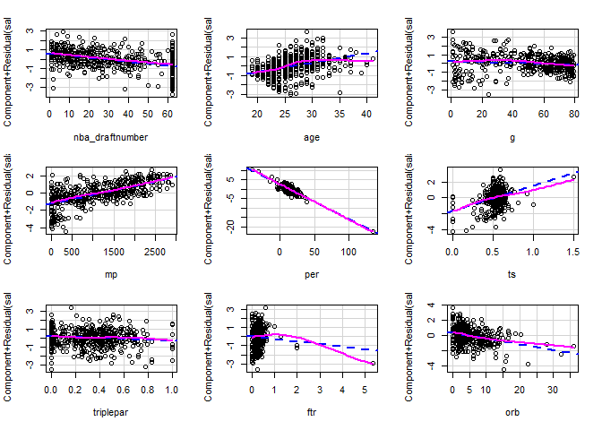

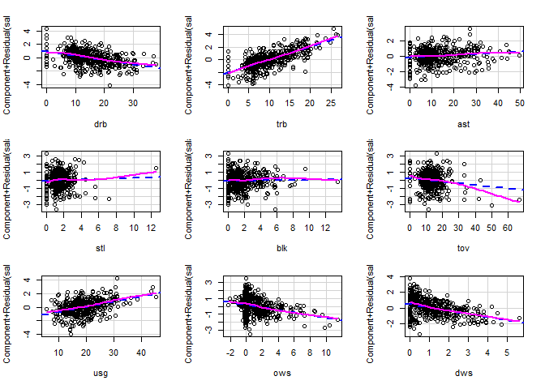

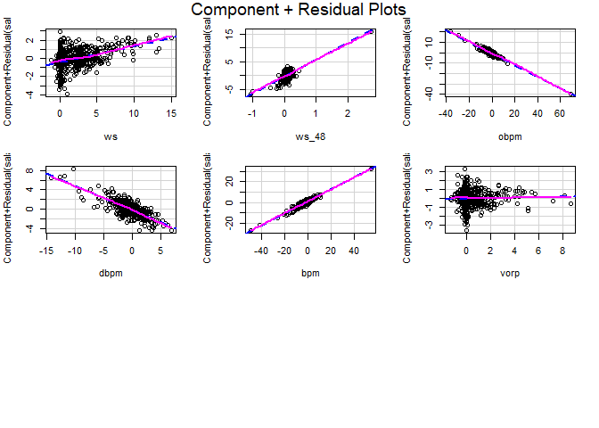

```r
crPlots(regresion_lm2)
```

### Varianza constante. Homoscedasticidad

La hipótesis nula es que la varianza es constante.

```r
ncvTest(regresion_lm2)
```

```
## Non-constant Variance Score Test
## Variance formula: ~ fitted.values
## Chisquare = 50.9249, Df = 1, p = 9.5968e-13
```

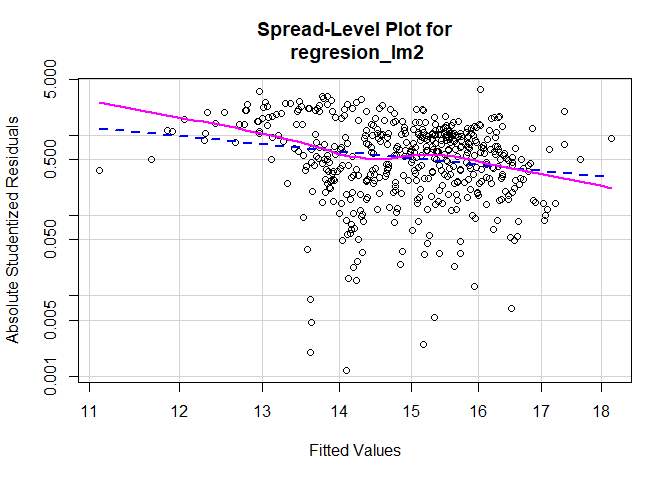

```
##
## Suggested power transformation:  3.887073
```

```r
spreadLevelPlot(regresion_lm2)
```

### Validación global

A continuación, realizaremos un gvlma, este test nos indica los p-valores de:

```r
gvmodel <- gvlma(regresion_lm2)
summary(gvmodel)
```

```
##
## Call:
## lm(formula = salary ~ . - (player + nba_country + tm), data = data_log_nba)
##
## Residuals:
##     Min      1Q  Median      3Q     Max
## -3.6467 -0.5503  0.0338  0.6031  3.3476
##
## Coefficients:
##                   Estimate Std. Error t value Pr(>|t|)
## (Intercept)     10.6956949  0.9742269  10.979  < 2e-16 ***
## nba_draftnumber -0.0220520  0.0025411  -8.678  < 2e-16 ***
## age              0.0994131  0.0112557   8.832  < 2e-16 ***
## g               -0.0050789  0.0049677  -1.022 0.307144
## mp               0.0010505  0.0002156   4.872 1.53e-06 ***
## per             -0.1836822  0.0558139  -3.291 0.001076 **
## ts               3.1723864  1.0240164   3.098 0.002069 **
## triplepar       -0.4079670  0.4691284  -0.870 0.384961
## ftr             -0.2894332  0.1764599  -1.640 0.101649
## orb             -0.0764709  0.1799375  -0.425 0.671047
## drb             -0.0631515  0.1781392  -0.355 0.723123
## trb              0.2063443  0.3566004   0.579 0.563116
## ast              0.0157191  0.0094577   1.662 0.097192 .
## stl              0.0359938  0.0839434   0.429 0.668281
## blk              0.0106909  0.0632854   0.169 0.865925
## tov             -0.0210089  0.0104781  -2.005 0.045551 *
## usg              0.0728828  0.0208889   3.489 0.000532 ***
## ows             -0.1698247  0.8965631  -0.189 0.849850
## dws             -0.4168086  0.9017950  -0.462 0.644159
## ws               0.1753680  0.8975693   0.195 0.845182
## ws_48            6.1696386  2.3458492   2.630 0.008827 **
## obpm            -0.5601645  0.9469549  -0.592 0.554450
## dbpm            -0.5030567  0.9301535  -0.541 0.588888
## bpm              0.5825235  0.9337111   0.624 0.533019
## vorp             0.0274218  0.1260476   0.218 0.827876
## ---
## Signif. codes:  0 '***' 0.001 '**' 0.01 '*' 0.05 '.' 0.1 ' ' 1
##
## Residual standard error: 1.015 on 456 degrees of freedom
## Multiple R-squared:  0.5586, Adjusted R-squared:  0.5354
## F-statistic: 24.04 on 24 and 456 DF,  p-value: < 2.2e-16
##
##
## ASSESSMENT OF THE LINEAR MODEL ASSUMPTIONS
## USING THE GLOBAL TEST ON 4 DEGREES-OF-FREEDOM:
## Level of Significance =  0.05
##
## Call:
##  gvlma(x = regresion_lm2)
##
##                       Value   p-value                   Decision
## Global Stat        42.17462 1.535e-08 Assumptions NOT satisfied!
## Skewness            6.98721 8.209e-03 Assumptions NOT satisfied!
## Kurtosis           11.44360 7.174e-04 Assumptions NOT satisfied!
## Link Function      23.71210 1.119e-06 Assumptions NOT satisfied!
## Heteroscedasticity  0.03171 8.587e-01    Assumptions acceptable.
```

Como podemos observar solo cumple la heteroscedastiicdad.

### Multicolinealidad

Para detectar la multicolinealidad se utiliza el Factor de inflación de varianza (VIF). Para cualquier regresor la raíz del VIF indica cuantas veces es la varianza del estimador es mayor que la que se obtendría si no hubiera correlación entre los regresores.

```r
vif(regresion_lm2)
```

```
## nba_draftnumber             age               g              mp             per
##        1.340171        1.078945        6.999197       14.172245      110.918970
##              ts       triplepar             ftr             orb             drb
##        6.146914        5.301979        1.264400      317.236811      684.388198
##             trb             ast             stl             blk             tov
##     1439.666086        3.445392        3.208627        5.305430        1.917592
##             usg             ows             dws              ws           ws_48
##        6.861721     1329.661494      405.100887     2683.730741       67.930181
##            obpm            dbpm             bpm            vorp
##    10524.307876     2307.119717    12928.849699       11.551583
```

```r
sqrt(vif(regresion_lm2)) > 2
```

```
## nba_draftnumber             age               g              mp             per
##           FALSE           FALSE            TRUE            TRUE            TRUE
##              ts       triplepar             ftr             orb             drb
##            TRUE            TRUE           FALSE            TRUE            TRUE
##             trb             ast             stl             blk             tov
##            TRUE           FALSE           FALSE            TRUE           FALSE
##             usg             ows             dws              ws           ws_48
##            TRUE            TRUE            TRUE            TRUE            TRUE
##            obpm            dbpm             bpm            vorp
##            TRUE            TRUE            TRUE            TRUE
```

En este caso, algunas de nuestras variables presentan problemas de multicolinealidad. Tiene sentido porque bpm depende de obpm y dbpm.

### Outliers

Comenzamos con los **VALORES ATÍTPICOS**:

```r
outlierTest(regresion_lm2)
```

```
## No Studentized residuals with Bonferroni p < 0.05
## Largest |rstudent|:
##      rstudent unadjusted p-value Bonferroni p
## 350 -3.731896          0.0002141      0.10298
```

Ahora, comprobaremos si se tratan de **VALORES EXTREMOS**:

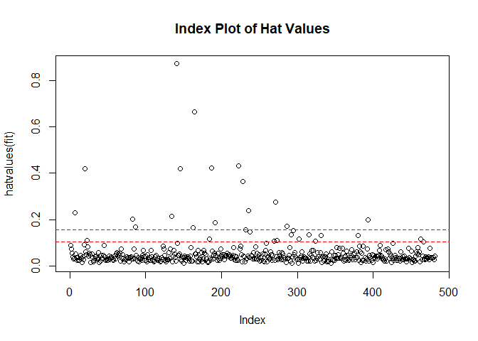

```
## integer(0)
```

```r
hat.plot <- function(fit) {
  p <- length(coefficients(fit))
  n <- length(fitted(fit))
  plot(hatvalues(fit), main = "Index Plot of Hat Values")
  abline(h = c(2,3) * p / n, col = "red", lty = 2)
  identify(1:n, hatvalues(fit), names(hatvalues(fit)))
}
hat.plot(regresion_lm2)
```

Por último, analizaremos los **VALORES INFLUYENTES**:

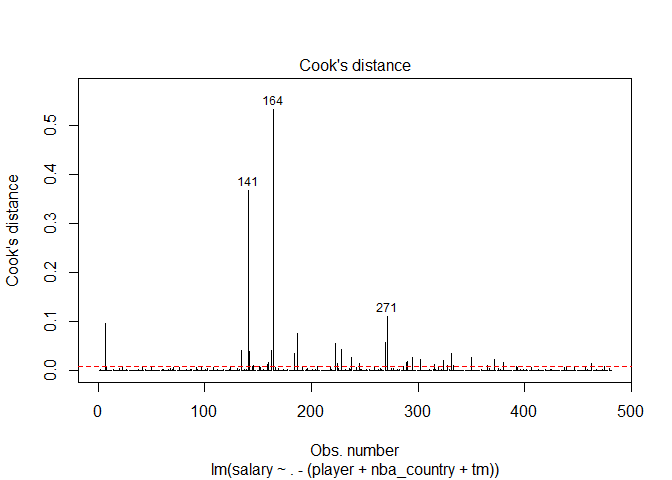

```r
cutoff <- 4 / (nrow(data_nba) - length(regresion_lm2$coefficients) - 2)
plot(regresion_lm2, which = 4, cook.levels = cutoff)
abline(h = cutoff, lty = 2, col = "red")
```

Vemos los valores influyentes: 141, 164, 271.

### Influence plot

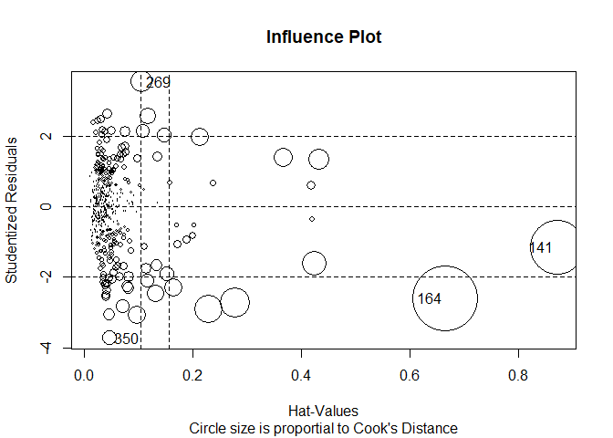

```
##       StudRes        Hat      CookD
## 141 -1.165064 0.87164596 0.36842568
## 164 -2.600972 0.66613625 0.53317412
## 269  3.532606 0.10595963 0.05770802
## 350 -3.731896 0.04635538 0.02633251
```

```r
influencePlot(regresion_lm2, id.method = "identify", main = "Influence Plot",
              sub = "Circle size is proportial to Cook's Distance" )
```

### CONCLUSIÓN:

Hemos conseguido mejorar el modelo inicial, pero sigue presentando problemas, para ello generaremos un modelo con los métodos de selección estudiados: *best subset*, *forward stepwise* y *backward stepwise*.

## MÉTODOS DE SELECCIÓN

### Best subset

Consiste en estimar todas las regresiones posibles con las combinaciones de los *p* regresores.

```r
regfit.full = regsubsets(salary ~ . -(player + nba_country + tm) ,data = data_log_nba)

reg.summary = summary(regfit.full)

reg.summary
```

```
## Subset selection object
## Call: regsubsets.formula(salary ~ . - (player + nba_country + tm),
##     data = data_log_nba)
## 24 Variables  (and intercept)
##                 Forced in Forced out
## nba_draftnumber     FALSE      FALSE
## age                 FALSE      FALSE
## g                   FALSE      FALSE
## mp                  FALSE      FALSE
## per                 FALSE      FALSE
## ts                  FALSE      FALSE
## triplepar           FALSE      FALSE
## ftr                 FALSE      FALSE
## orb                 FALSE      FALSE
## drb                 FALSE      FALSE
## trb                 FALSE      FALSE
## ast                 FALSE      FALSE
## stl                 FALSE      FALSE
## blk                 FALSE      FALSE
## tov                 FALSE      FALSE
## usg                 FALSE      FALSE
## ows                 FALSE      FALSE
## dws                 FALSE      FALSE
## ws                  FALSE      FALSE
## ws_48               FALSE      FALSE
## obpm                FALSE      FALSE
## dbpm                FALSE      FALSE
## bpm                 FALSE      FALSE
## vorp                FALSE      FALSE
## 1 subsets of each size up to 8
## Selection Algorithm: exhaustive
##          nba_draftnumber age g   mp  per ts  triplepar ftr orb drb trb ast stl
## 1  ( 1 ) " "             " " " " "*" " " " " " "       " " " " " " " " " " " "
## 2  ( 1 ) "*"             " " " " "*" " " " " " "       " " " " " " " " " " " "
## 3  ( 1 ) "*"             "*" " " "*" " " " " " "       " " " " " " " " " " " "
## 4  ( 1 ) "*"             "*" " " "*" " " " " " "       " " " " "*" " " " " " "
## 5  ( 1 ) "*"             "*" " " "*" " " " " " "       " " " " "*" " " " " " "
## 6  ( 1 ) "*"             "*" " " "*" "*" "*" " "       " " " " "*" " " " " " "
## 7  ( 1 ) "*"             "*" " " "*" "*" " " "*"       " " " " "*" " " " " " "
## 8  ( 1 ) "*"             "*" " " "*" "*" "*" " "       " " " " "*" " " " " " "
##          blk tov usg ows dws ws  ws_48 obpm dbpm bpm vorp
## 1  ( 1 ) " " " " " " " " " " " " " "   " "  " "  " " " "
## 2  ( 1 ) " " " " " " " " " " " " " "   " "  " "  " " " "
## 3  ( 1 ) " " " " " " " " " " " " " "   " "  " "  " " " "
## 4  ( 1 ) " " " " " " " " " " " " " "   " "  " "  " " " "
## 5  ( 1 ) " " " " " " " " " " " " " "   " "  "*"  " " " "
## 6  ( 1 ) " " " " " " " " " " " " " "   " "  " "  " " " "
## 7  ( 1 ) " " " " " " " " " " " " " "   "*"  " "  " " " "
## 8  ( 1 ) " " " " "*" " " " " " " " "   " "  " "  "*" " "
```

A continuación, veremos cuál es el mejor:

```r
df_bestsubset <- data.frame(Adj.R2 = (reg.summary$adjr2),
                            CP = (reg.summary$cp),
                            BIC = (reg.summary$bic)
                           )
df_bestsubset
```

```
##      Adj.R2         CP       BIC
## 1 0.3375086 205.959135 -186.7020
## 2 0.4341786 107.084692 -257.3991
## 3 0.5155746  24.306590 -326.9371
## 4 0.5271490  13.406788 -333.4027
## 5 0.5268759  14.668251 -327.9608
## 6 0.5292859  13.191528 -325.2549
## 7 0.5309770  12.456919 -321.8261
## 8 0.5345856   9.781848 -320.3832
```

Como vemos, el mejor es modelo que incluye las 8 variables.

```r
regresion_lm3 <- lm(salary ~ nba_draftnumber + age + mp + per + ts + drb + usg + bpm, data = data_log_nba)

summary(regresion_lm3)
```

```
##
## Call:
## lm(formula = salary ~ nba_draftnumber + age + mp + per + ts +
##     drb + usg + bpm, data = data_log_nba)
##
## Residuals:
##     Min      1Q  Median      3Q     Max
## -3.4162 -0.5496  0.0435  0.6259  3.4124
##
## Coefficients:
##                   Estimate Std. Error t value Pr(>|t|)
## (Intercept)      1.119e+01  5.063e-01  22.100  < 2e-16 ***
## nba_draftnumber -2.281e-02  2.430e-03  -9.387  < 2e-16 ***
## age              9.959e-02  1.095e-02   9.094  < 2e-16 ***
## mp               6.720e-04  7.772e-05   8.647  < 2e-16 ***
## per             -5.823e-02  1.758e-02  -3.313 0.000995 ***
## ts               1.640e+00  7.138e-01   2.298 0.021990 *
## drb              3.042e-02  7.258e-03   4.191 3.32e-05 ***
## usg              3.006e-02  1.234e-02   2.437 0.015199 *
## bpm              5.826e-02  2.359e-02   2.470 0.013878 *
## ---
## Signif. codes:  0 '***' 0.001 '**' 0.01 '*' 0.05 '.' 0.1 ' ' 1
##
## Residual standard error: 1.016 on 472 degrees of freedom
## Multiple R-squared:  0.5423, Adjusted R-squared:  0.5346
## F-statistic: 69.92 on 8 and 472 DF,  p-value: < 2.2e-16
```

### Step AIC “both”

Vamos a probar con otro método para ver si obtenemos un mayor R2:

```r
stepAIC(regresion_lm2, direction = "both")
```

```
## Start:  AIC=38.4
## salary ~ (player + nba_country + nba_draftnumber + age + tm +
##     g + mp + per + ts + triplepar + ftr + orb + drb + trb + ast +
##     stl + blk + tov + usg + ows + dws + ws + ws_48 + obpm + dbpm +
##     bpm + vorp) - (player + nba_country + tm)
##
##                   Df Sum of Sq    RSS     AIC
## - blk              1     0.029 469.57  36.429
## - ows              1     0.037 469.57  36.436
## - ws               1     0.039 469.58  36.439
## - vorp             1     0.049 469.59  36.449
## - drb              1     0.129 469.67  36.531
## - orb              1     0.186 469.72  36.589
## - stl              1     0.189 469.73  36.593
## - dws              1     0.220 469.76  36.624
## - dbpm             1     0.301 469.84  36.707
## - trb              1     0.345 469.88  36.752
## - obpm             1     0.360 469.90  36.768
## - bpm              1     0.401 469.94  36.809
## - triplepar        1     0.779 470.32  37.196
## - g                1     1.076 470.61  37.500
## <none>                         469.54  38.399
## - ftr              1     2.770 472.31  39.228
## - ast              1     2.844 472.38  39.304
## - tov              1     4.139 473.68  40.621
## - ws_48            1     7.122 476.66  43.640
## - ts               1     9.882 479.42  46.417
## - per              1    11.152 480.69  47.689
## - usg              1    12.535 482.07  49.071
## - mp               1    24.437 493.97  60.803
## - nba_draftnumber  1    77.543 547.08 109.919
## - age              1    80.325 549.86 112.358
##
## Step:  AIC=36.43
## salary ~ nba_draftnumber + age + g + mp + per + ts + triplepar +
##     ftr + orb + drb + trb + ast + stl + tov + usg + ows + dws +
##     ws + ws_48 + obpm + dbpm + bpm + vorp
##
##                   Df Sum of Sq    RSS     AIC
## - ows              1     0.041 469.61  34.471
```

[output cut: 325 more lines]

```
## + stl              1     0.180 474.77  23.732
## + blk              1     0.176 474.78  23.735
## + drb              1     0.001 474.95  23.913
## + orb              1     0.000 474.95  23.913
## - ast              1     4.095 479.05  24.043
## - tov              1     4.927 479.88  24.878
## - ws_48            1     7.447 482.40  27.397
## - bpm              1     8.666 483.62  28.611
## - ts               1    10.826 485.78  30.754
## - usg              1    12.881 487.83  32.785
## - trb              1    15.910 490.86  35.762
## - per              1    16.307 491.26  36.151
## - mp               1    45.775 520.73  64.172
## - age              1    85.321 560.27  99.380
## - nba_draftnumber  1    88.072 563.02 101.736
```

```
##
## Call:
## lm(formula = salary ~ nba_draftnumber + age + mp + per + ts +
##     trb + ast + tov + usg + dws + ws_48 + obpm + bpm, data = data_log_nba)
##
## Coefficients:
##     (Intercept)  nba_draftnumber              age               mp
##      10.4275139       -0.0227170        0.1008459        0.0008984
##             per               ts              trb              ast
##      -0.1504302        2.7685540        0.0635338        0.0158707
##             tov              usg              dws            ws_48
##      -0.0209205        0.0697581       -0.2035242        5.2285620
##            obpm              bpm
##      -0.0926688        0.0974013
```

```r
regresion_lm4 <- lm(salary ~ nba_draftnumber + age + mp + per + ts +  trb + ast + tov + usg + dws + ws_48 + obpm + bpm,
                    data = data_log_nba)

summary(regresion_lm4)
```

```
##
## Call:
## lm(formula = salary ~ nba_draftnumber + age + mp + per + ts +
##     trb + ast + tov + usg + dws + ws_48 + obpm + bpm, data = data_log_nba)
##
## Residuals:
##     Min      1Q  Median      3Q     Max
## -3.5785 -0.5507  0.0220  0.6354  3.3913
##
## Coefficients:
##                   Estimate Std. Error t value Pr(>|t|)
## (Intercept)     10.4275139  0.6350750  16.419  < 2e-16 ***
## nba_draftnumber -0.0227170  0.0024412  -9.306  < 2e-16 ***
## age              0.1008459  0.0110102   9.159  < 2e-16 ***
## mp               0.0008984  0.0001339   6.709 5.69e-11 ***
## per             -0.1504302  0.0375675  -4.004 7.24e-05 ***
## ts               2.7685540  0.8485702   3.263 0.001185 **
## trb              0.0635338  0.0160636   3.955 8.84e-05 ***
## ast              0.0158707  0.0079093   2.007 0.045368 *
## tov             -0.0209205  0.0095047  -2.201 0.028219 *
## usg              0.0697581  0.0196011   3.559 0.000411 ***
## dws             -0.2035242  0.1103193  -1.845 0.065690 .
## ws_48            5.2285620  1.9321882   2.706 0.007058 **
## obpm            -0.0926688  0.0577384  -1.605 0.109175
## bpm              0.0974013  0.0333677   2.919 0.003681 **
## ---
## Signif. codes:  0 '***' 0.001 '**' 0.01 '*' 0.05 '.' 0.1 ' ' 1
##
## Residual standard error: 1.008 on 467 degrees of freedom
## Multiple R-squared:  0.5535, Adjusted R-squared:  0.5411
## F-statistic: 44.53 on 13 and 467 DF,  p-value: < 2.2e-16
```

Como vemos este modelo es mejor que el anterior ya que tiene mayor R2, aún así compararemos los AIC de los modelos 3 y 4:

```r
AIC(regresion_lm3, regresion_lm4)
```

```
##               df      AIC
## regresion_lm3 10 1390.801
## regresion_lm4 15 1388.933
```

Como podemos ver el AIC del modelo 4 ( *regresion_lm4* ) es menor que el 3, por lo tanto, seleccionamos el modelo 4.

## CROSS VALIDATION

```r
# Definimos nuestras funciones
shrinkage <- function(fit, k = 10){
  require(bootstrap)

theta.fit <- function(x, y){lsfit(x,y)}
theta.predict <- function(fit, x){cbind(1, x) %*% fit$coef}

x <- fit$model[,2:ncol(fit$model)]
y <- fit$model[,1]
results <- crossval(x, y, theta.fit, theta.predict, ngroup=k)
r2 <- cor(y, fit$fitted.values)^2
r2cv <- cor(y, results$cv.fit)^2
cat("Original R-square =", r2, "\n")
cat(k, "Fold Cross-Validated R-square =", r2cv, "\n")
cat("Change =", r2-r2cv, "\n")
}

# Aplicamos la funcion a nuestro modelo
shrinkage(regresion_lm4)
```

```
## Original R-square = 0.553497
## 10 Fold Cross-Validated R-square = 0.4272898
## Change = 0.1262072
```

## IMPORTANCIA RELATIVA

En este apartado calcularemos los *relative weights*:

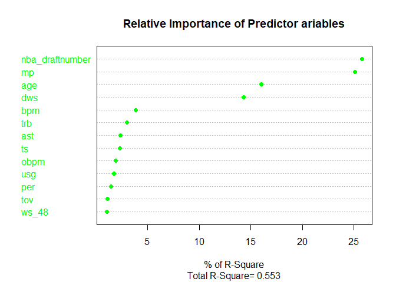

```
##                   Weights
## ws_48            1.066285
## tov              1.090415
## per              1.474107
## usg              1.732081
## obpm             1.932342
## ts               2.316792
## ast              2.364164
## trb              2.990160
## bpm              3.841761
## dws             14.320429
## age             15.990433
## mp              25.108798
## nba_draftnumber 25.772232
```

```r
# Definimos la funcion
relweights <- function(fit,...){
  R <- cor(fit$model)
  nvar <- ncol(R)
  rxx <- R[2:nvar, 2:nvar]
  rxy <- R[2:nvar, 1]
  svd <- eigen(rxx)
  evec <- svd$vectors
  ev <- svd$values
  delta <- diag(sqrt(ev))
  lambda <- evec %*% delta %*% t(evec)
  lambdasq <- lambda ^ 2
  beta <- solve(lambda) %*% rxy
  rsquare <- colSums(beta ^ 2)
  rawwgt <- lambdasq %*% beta ^ 2
  import <- (rawwgt / rsquare) * 100
  import <- as.data.frame(import)
  row.names(import) <- names(fit$model[2:nvar])
  names(import) <- "Weights"
  import <- import[order(import),1, drop = FALSE]
  dotchart(import$Weights, labels = row.names(import), xlab = "% of R-Square", pch = 19,
           main = "Relative Importance of Predictor ariables",
           sub = paste("Total R-Square=", round(rsquare, digits = 3)),
           ...)
return(import)
}

# Aplicamos la funcion
relweights(regresion_lm4, col = "green")
```

Gracias a este gráfico somos capaces de observar el porcentaje de R2 que explica cada variable. De esta manera, las más importantes son nba_draftnumber y mp, seguidas de age y dws.

## PREDICCIÓN

Para finalizar este ejercicio vamos a predecir el salario de uno de los jugadores, en concreto, el de Marc Gasol:

```r
pred.ind <- data.frame(nba_draftnumber = 48, mp = 2374, age = 33, dws = 2.6, bpm = 1.5, trb = 14.2, ast = 21.5, ts = 0.531,
                       obpm = -0.2, usg = 25.7, per = 17.3, tov = 14.1, ws_48 = 0.080)
pred.ind
```

```
##   nba_draftnumber   mp age dws bpm  trb  ast    ts obpm  usg  per  tov ws_48
## 1              48 2374  33 2.6 1.5 14.2 21.5 0.531 -0.2 25.7 17.3 14.1  0.08
```

```r
predict(regresion_lm4, newdata = pred.ind)
```

```
##        1
## 16.46051
```

En el df su salario en logaritmo es 16.93533, por lo que si nuestro modelo es preciso, podemos concluir que este jugador está sobrevalorado, ya que el salario real es mayor que el estimado.

```r
# Establecemos la semilla 1234 para obtener los mismos resultados
set.seed(1234)

# Seleccionaremos 10 muestras para la prediccion
n <- 10

# Creamos nuestra muestra sin datos repetidos

ind <- sample(1:nrow(data_log_nba), n, replace = FALSE)
muestra <- data_log_nba[ind,]
muestra <- data.frame(muestra)
muestra
```

```
##              player   salary nba_country nba_draftnumber age  tm  g   mp  per
## 1     Jarrett Allen 14.35418         USA              22  19 BRK 68 1341 17.6
## 2    Furkan Korkmaz 14.19799      Turkey              26  20 PHI 12   69  6.5
## 3        Damion Lee 11.43128         USA              62  25 ATL 12  321 12.9
## 4    Reggie Jackson 16.58810         USA              24  27 DET 41 1084 15.5
## 5       Paul Zipser 14.08753     Germany              48  23 CHI 54  824  5.2
## 6    David Stockton 11.90711         USA              62  26 UTA  2    6 31.4
## 7       Nigel Hayes 11.43128         USA              62  23 TOT  6   60  2.4
## 8     Cheick Diallo 14.08753        Mali              33  21 NOP 48  538 17.4
## 9  Dante Cunningham 14.64842         USA              33  30 TOT 70 1499  9.7
## 10  DeAndre' Bembry 14.26480         USA              21  23 ATL 23  395  6.2
##       ts triplepar   ftr  orb  drb  trb  ast stl blk  tov  usg  ows dws   ws
## 1  0.634     0.037 0.387 10.9 17.7 14.3  5.6 1.0 4.1 15.3 16.7  2.5 1.3  3.9
## 2  0.446     0.625 0.167  3.3 13.6  8.6  6.0 1.4 1.2  7.2 17.2  0.0 0.1  0.0
## 3  0.496     0.387 0.210  3.1 15.7  9.4 11.7 2.6 0.3  7.8 19.2  0.1 0.3  0.4
```

[output cut: 18 more lines]

Esa es la muestra de jugadores que hemos obtenido con sus salarios, a continuación, predeciremos lo salarios de esto jugadores.

```r
# Predecimos el salario de los jugadores
predict(regresion_lm4, newdata = muestra)
```

```
##        1        2        3        4        5        6        7        8
## 14.57245 13.84765 13.44094 15.14788 13.90957 13.12526 12.28671 14.33261
##        9       10
## 15.52834 14.18365
```

Como podemos observar, existen diferencias entre nuestro modelo y la realidad, esto puede explicarse porque el modelo seleccionado no es del todo preciso y/o que ciertos jugadores están infravalorados y sobrevalorados.